# Age and Happiness: Does Gender Make a Difference?

Xiaojing Dong UNI: xd2195

As Plato said, *all human beings natually desire happiness*, which raises a question about what exactly makes people happy. Do the sources of happiness change with age? Are there gender difference?

To answer the above questions, let us analyze the HappyDB datasets, “a corpus of 100,000 crowd-sourced happy moments”, and try to understand the relationship between age, gender and happiness.

## Word counts of original happy moments

First, let us look at the word counts of original happy moments.

- According to the boxplot, we can see the female tend to use slightly more words to describe their happy moments than men do.
- If we compare the number of words across age, then there is no significant difference.

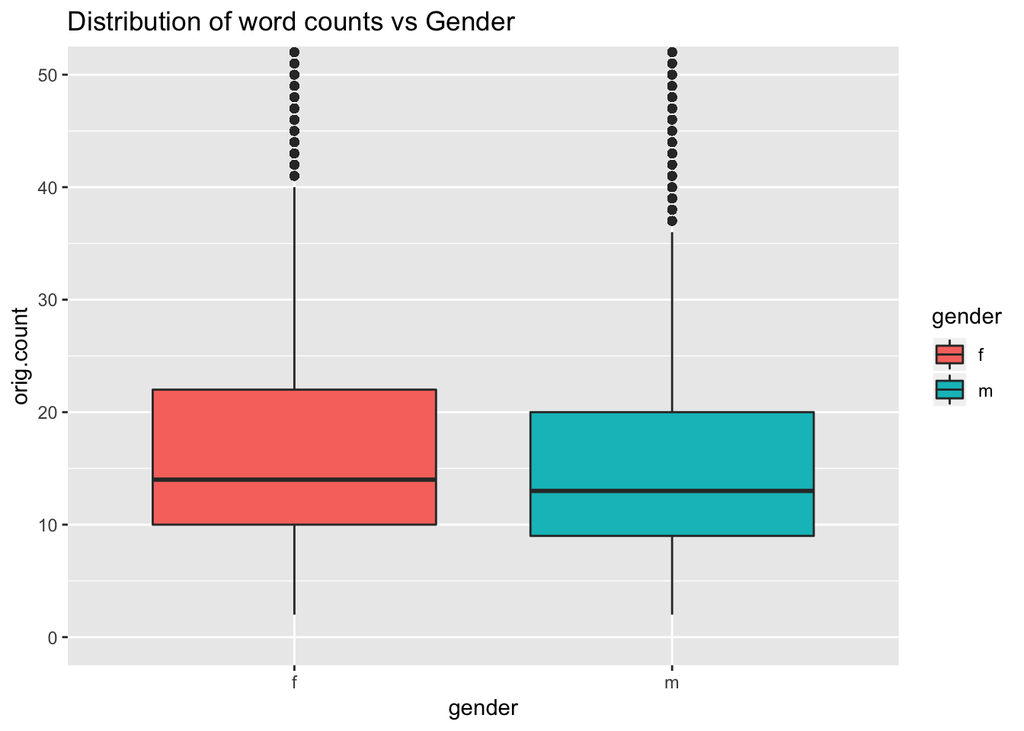

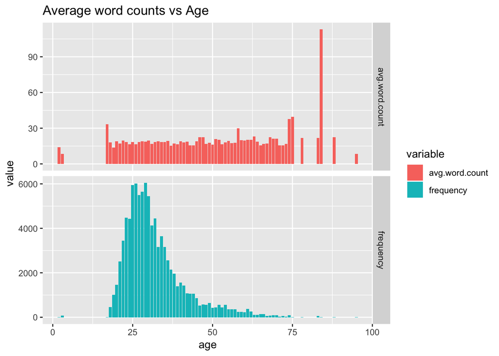

## Topic analysis

### Sources of happiness with respect to age

To explore the relationship between age and happiness, let us use heatmap to visualize the weight allocation of each topic with respect to age.

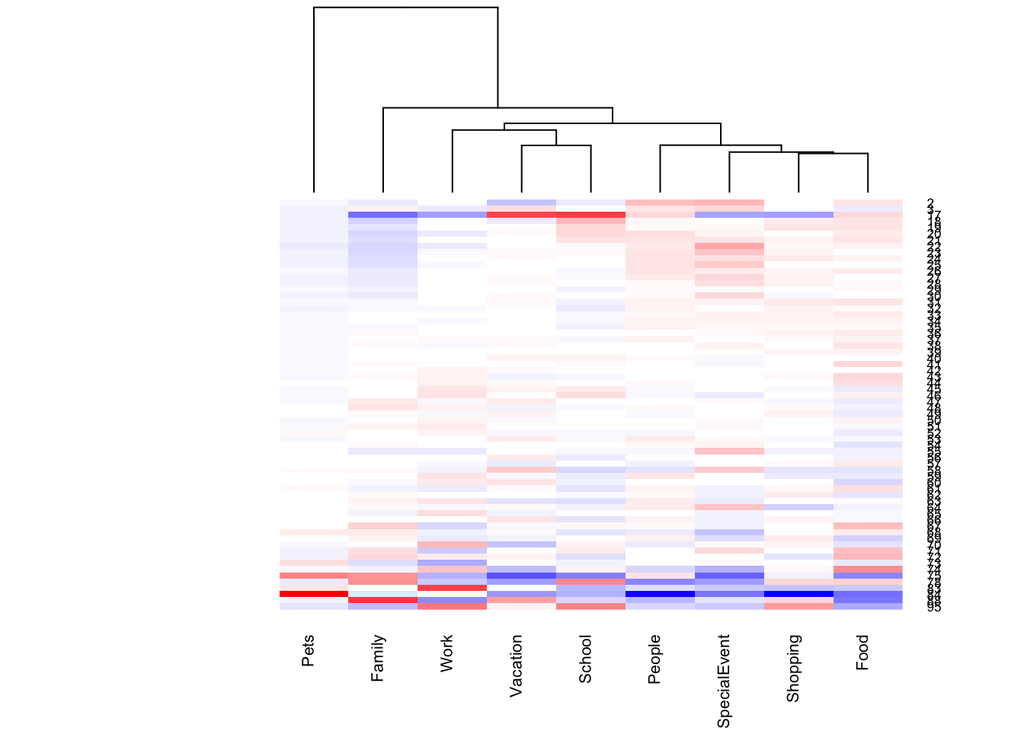

- For the teenagers under the age of 20, we can see **School** and **Vacation** are the most important sources of happiness.
- When the young teenagers turn 20, they tend to care more about the leisurement and their social lifes, such as **Special Event**, **People** and **Shopping**.
- For the middle-aged people between 45 and 65, **Work** and **Family** become the most important sources of happiness, while **Food** becomes less important. We can also observe that **School** shows another peak around the age of 45, which may be because their children.
- For the elderly people, **Family** and **Pets** tend to carry more weights, which suggest that the elderly need more companionship.

Moreover, if we look at the weight allocation of each topic with respect to marital status and parenthood, we find that after getting married and/or having a child, **Family**, **Vacation** and **Special Event** appear to make people happier than before.

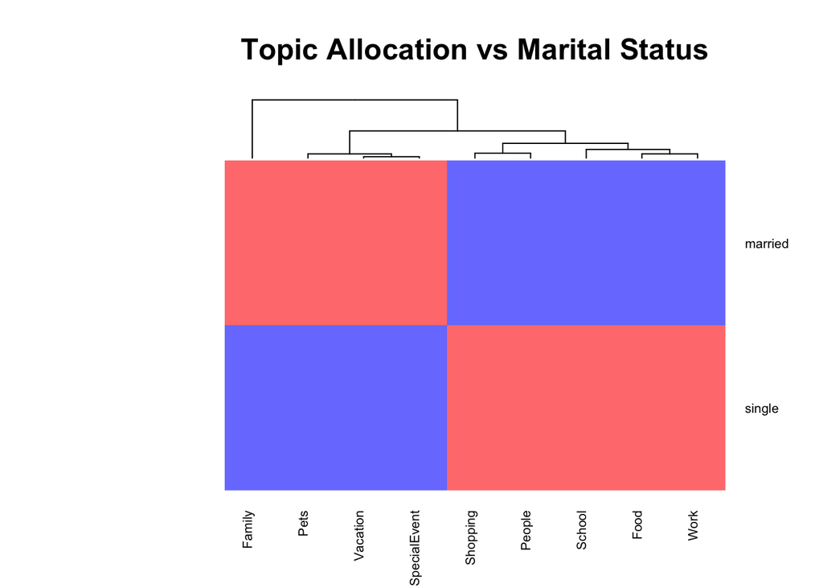

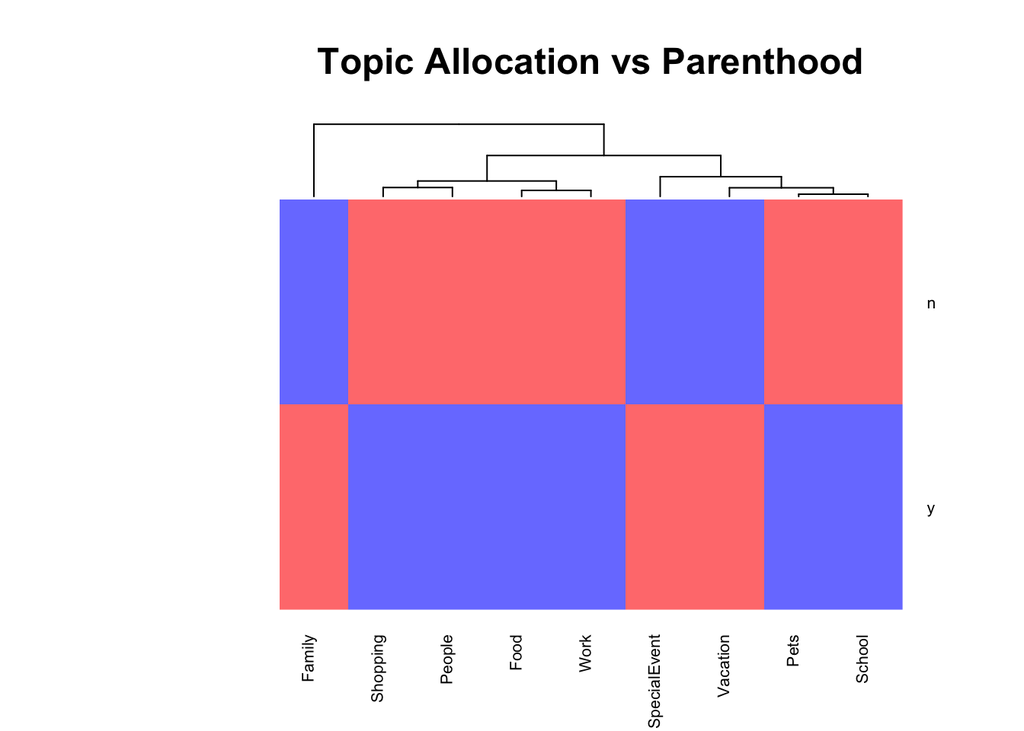

### Are there gender differences?

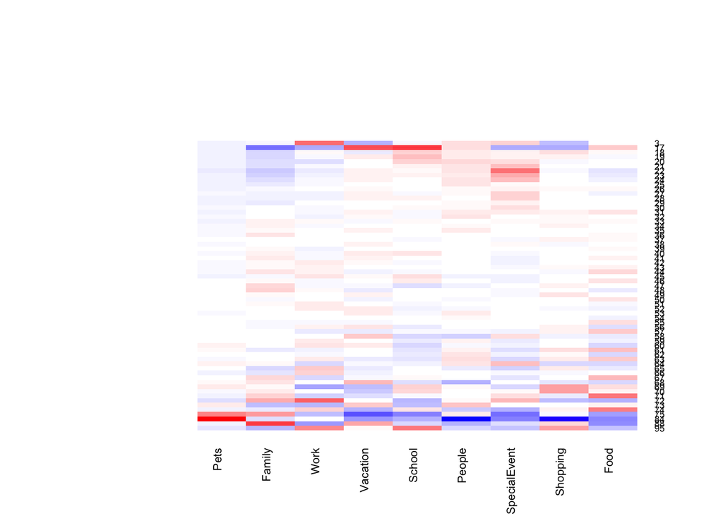

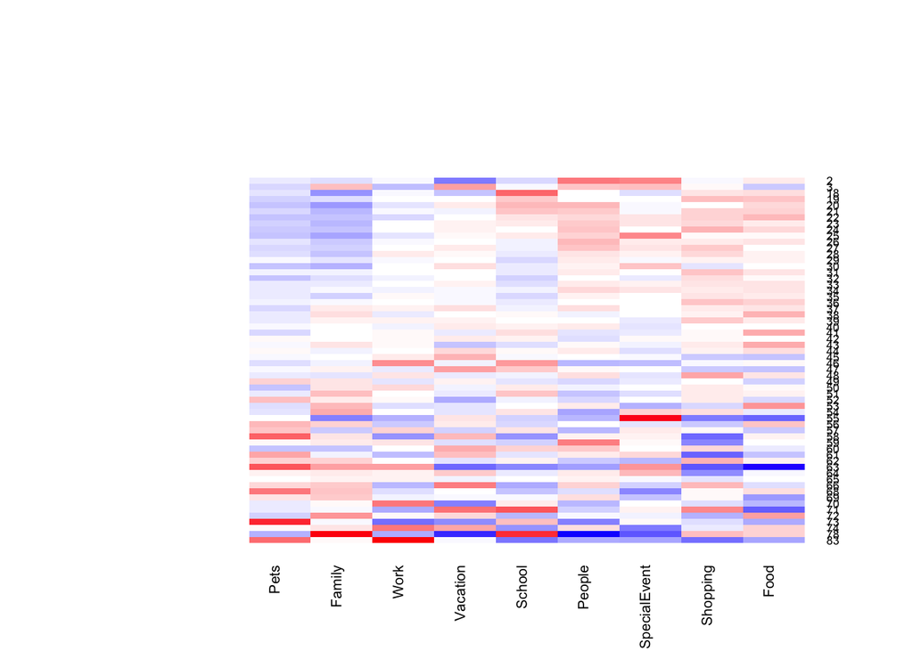

An interesting observation is that, under the age of 45, **Shopping** seems to make men much happier than women. Although we may think women like to shop more than men do, our analysis suggests that, under the age of 45, **Shopping** is a big source of happiness for the male, while the female care more about the emotional connection, such as **People** and **Special Event**.

On the other hand, we can observe that men do not put much weights on **Family** until the age of 40, which is obviously a higher age than women.

## References

1. HappyDB: A Corpus of 100,000 Crowdsourced Happy Moments from https://arxiv.org/pdf/1801.07746.pdf
2. The Effect of Gender and Age on Happiness from https://www.gaiashomes.com/gender-age-happiness/